# Alaska Early and Absentee Voting 2020 Entire. Hopefully works.

Ben Matheson

10/16/2020

## Introduction

The data come from the [Alaska Division of Elections website](https://www.elections.alaska.gov/results/20GENR/data/sovc/CombinedBallotCountReport_Server.pdf) It’s a 10-page pdf, so I ran a script using tabula-py to extract the data. Additional summary information is available [here](https://www.elections.alaska.gov/doc/info/statstable.php).

I have republished the data in a [Google Sheet](https://docs.google.com/spreadsheets/d/1Nmlp7l2ucGn05AyH7sqvos1Qn2SRSZxjytsQxlAu8ss/edit?usp=sharing), which is available [here](https://docs.google.com/spreadsheets/d/1Nmlp7l2ucGn05AyH7sqvos1Qn2SRSZxjytsQxlAu8ss/edit?usp=sharing). From Google Sheets, you can download as a CSV or .xlsx or whatever. If you see any errors, contact [Ben Matheson](https://twitter.com/benmatheson). *Disclaimer - this may not be fully accurate or up to date. It also may break at any time.* This is not official or affiliated with anything.

## Vote By Mail

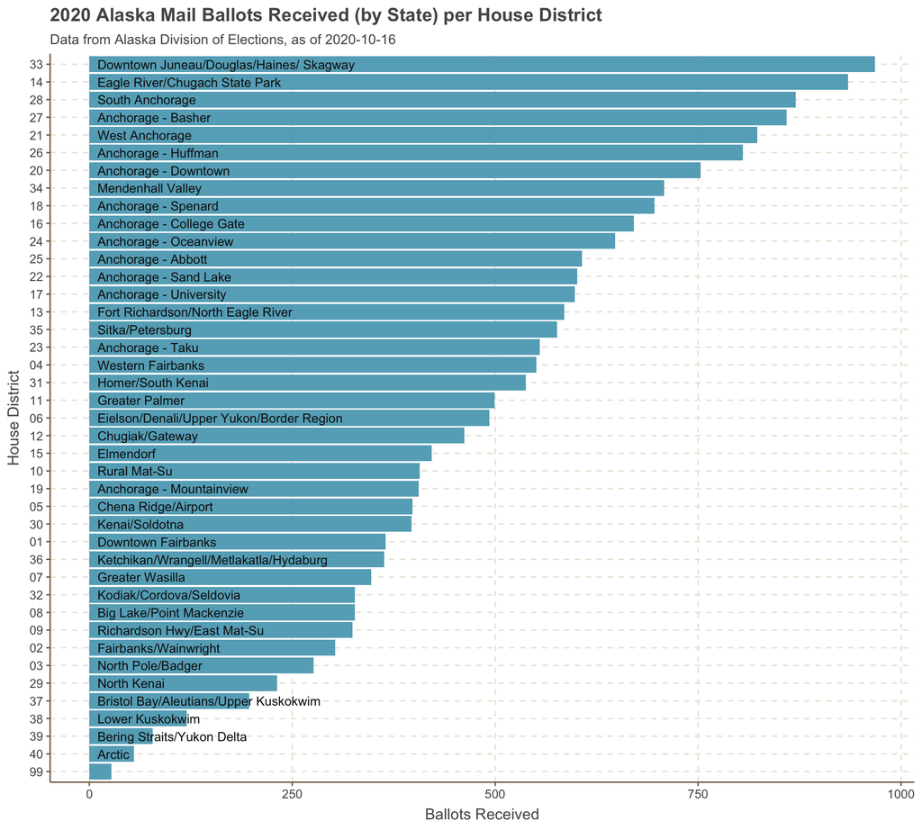

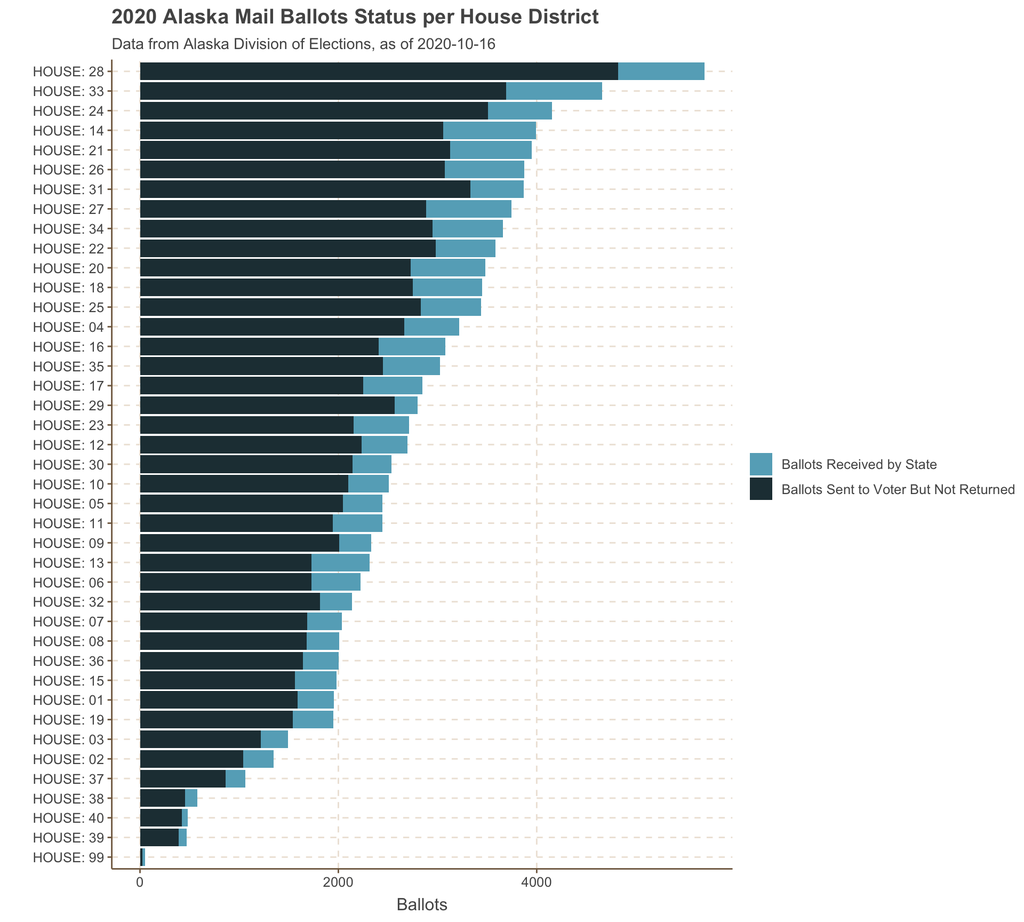

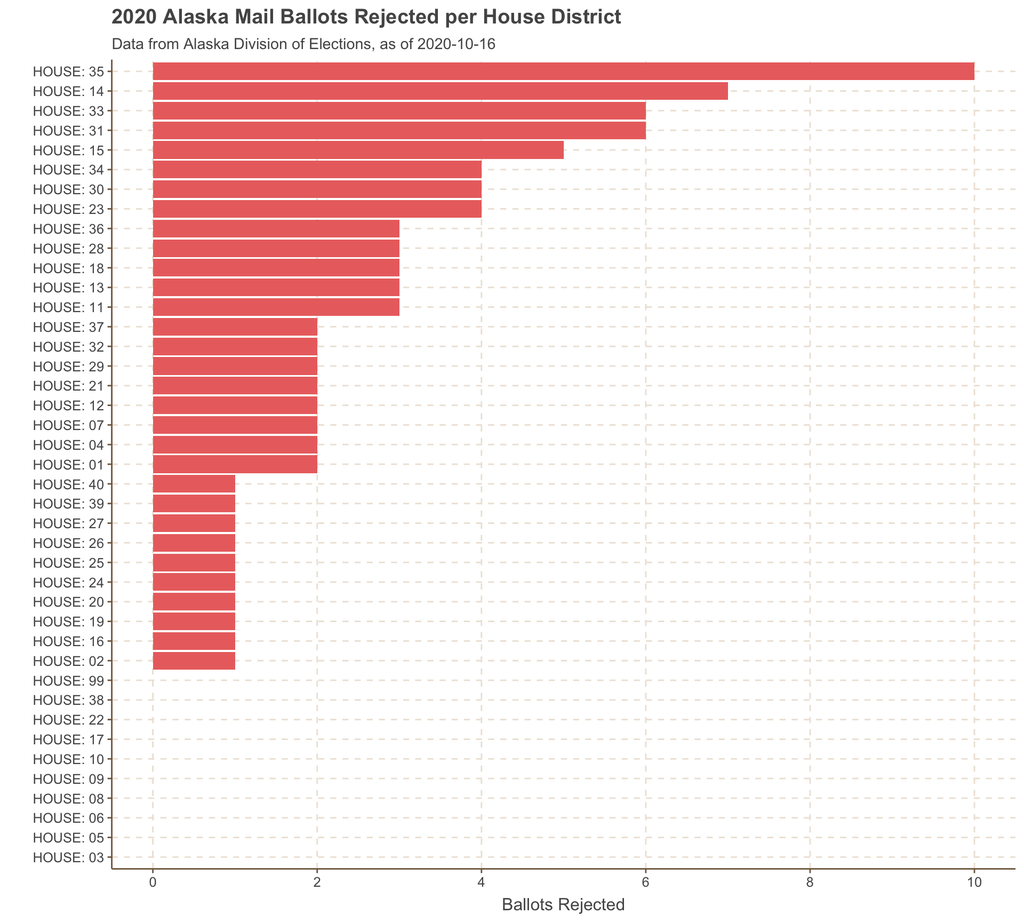

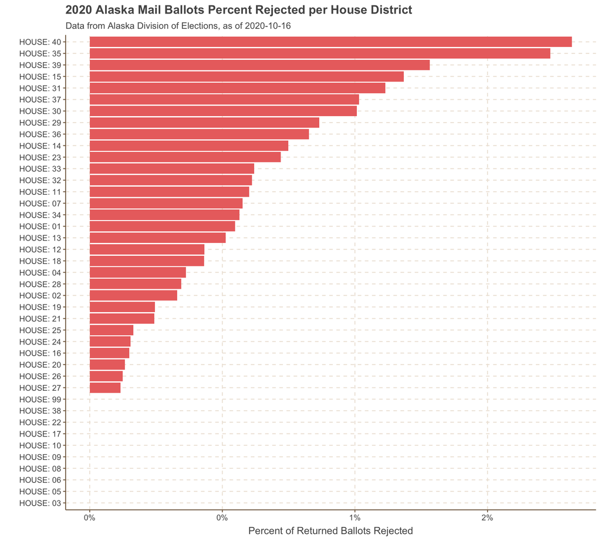

## Early Voting

Early voting starts October 19th. Once that data appears, it will be here.

## Mail Ballots Sent, Received, and Rejected

| district_number | district_description | ballots_sent | ballots_received | reject |
| --- | --- | --- | --- | --- |
| 33 | Downtown Juneau/Douglas/Haines/ Skagway | 4661 | 968 | 6 |
| 14 | Eagle River/Chugach State Park | 3992 | 935 | 7 |
| 28 | South Anchorage | 5690 | 870 | 3 |
| 27 | Anchorage - Basher | 3746 | 859 | 1 |
| 21 | West Anchorage | 3952 | 823 | 2 |
| 26 | Anchorage - Huffman | 3876 | 805 | 1 |
| 20 | Anchorage - Downtown | 3484 | 753 | 1 |
| 34 | Mendenhall Valley | 3659 | 708 | 4 |
| 18 | Anchorage - Spenard | 3447 | 696 | 3 |
| 16 | Anchorage - College Gate | 3079 | 671 | 1 |

[output cut: 31 more lines]

## Breakdown by House District

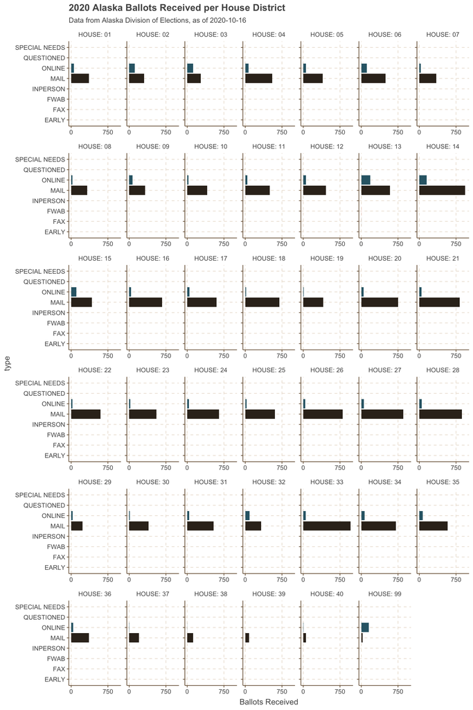

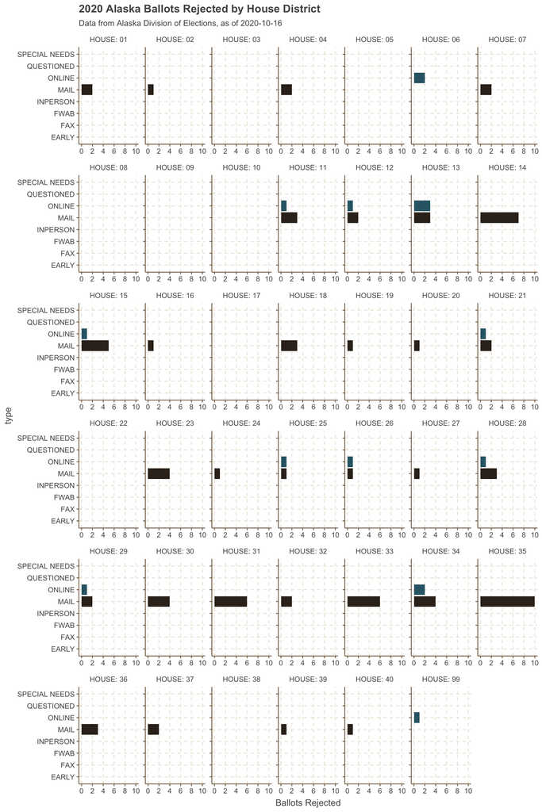

## About

The Alaska Division of Elections data is originally is published in a 10-page PDF that I parsed to extract the data. This uses a combination of R and Python. The Python uses Tabula to pull out the data. After that, an R script cleans out extra spaces, gaps, and labels the rows by house district and adds descriptions.

This webpage is an RMarkdown document that calculates some sumary stats, like percent rejected and then displays the data in several ggplot2 plots. The PDF parsing in particular may be brittle and this could break at anytime.